# 市场观察

2016/07/28

## 一、指数估值

### (一)指数动态市盈率

核心指数成分股的动态市盈率中位数走势如下图所示：

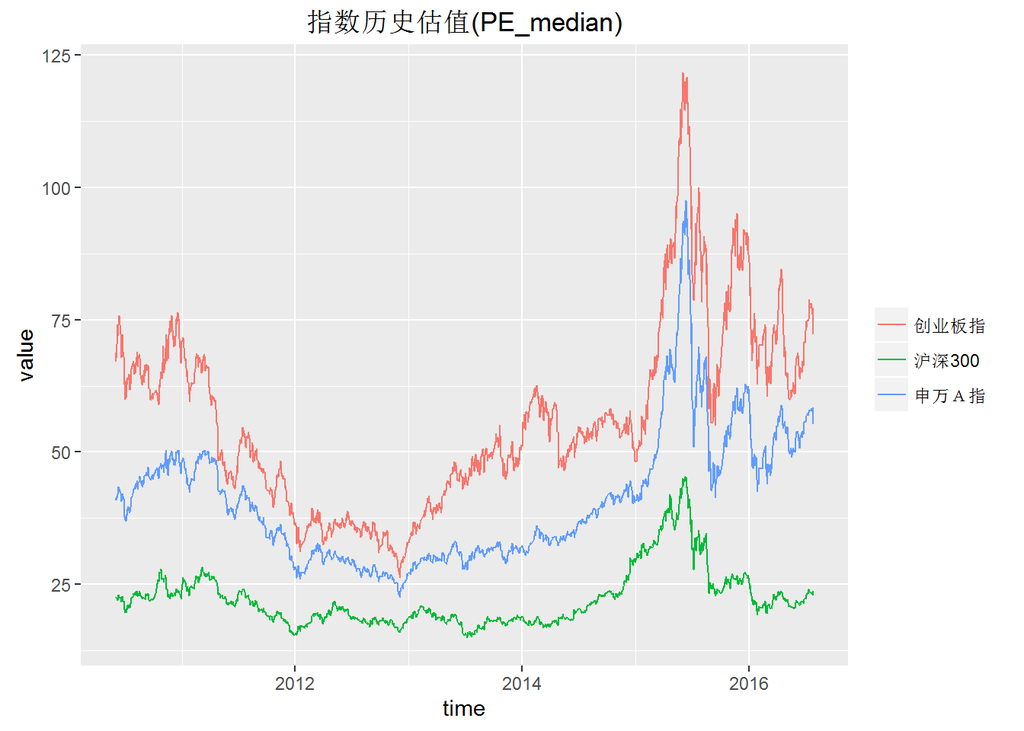

### (二)指数动态市盈率百分位

核心指数上述数据的百分位走势如下图所示：

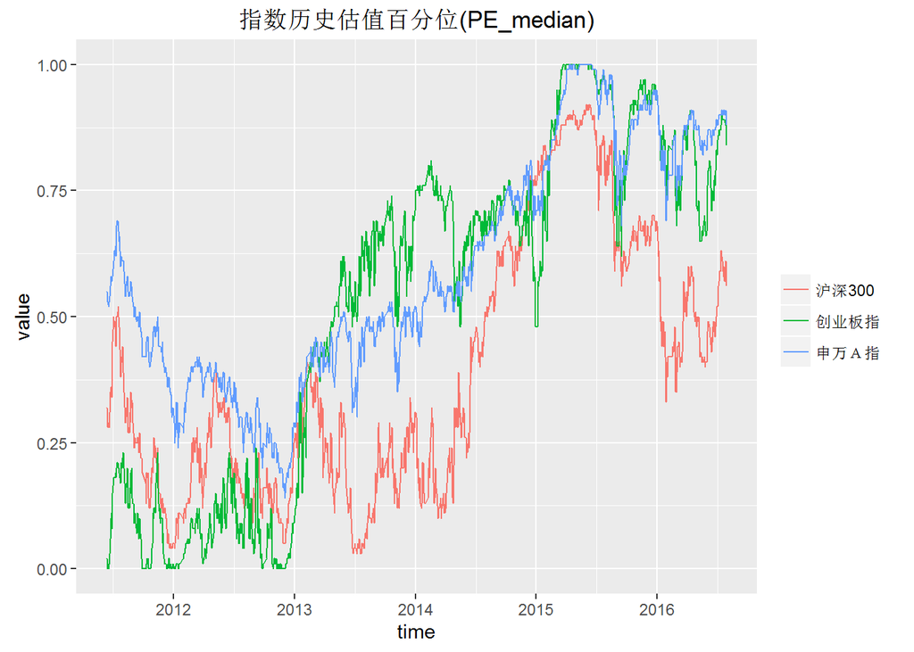

### (三)指数估值概览

纳入观察的18只指数最新的估值情况如下表：

| 日期 | 指数代码 | 指数简称 | 动态市盈率 | 上周动态市盈率 | 市盈率百分位 | 上周市盈率百分位 | 动态市净率 | 市净率百分位 |
| --- | --- | --- | --- | --- | --- | --- | --- | --- |
| 2016-07-27 | EI000979 | 大宗商品 | 47.04 | 49.78 | 0.94 | 0.96 | 2.46 | 0.42 |
| 2016-07-27 | EI000819 | 有色金属 | 63.58 | 66.67 | 0.90 | 0.94 | 4.16 | 0.85 |
| 2016-07-27 | EI801003 | 申万Ａ指 | 55.27 | 57.86 | 0.88 | 0.91 | 4.76 | 0.74 |
| 2016-07-27 | EI399005 | 中小板指P | 47.95 | 48.90 | 0.84 | 0.86 | 5.68 | 0.73 |
| 2016-07-27 | EI399006 | 创业板指 | 72.29 | 78.13 | 0.84 | 0.89 | 7.98 | 0.80 |
| 2016-07-27 | EI399959 | 军工指数 | 97.21 | 100.77 | 0.83 | 0.86 | 6.42 | 0.80 |
| 2016-07-27 | EI000805 | A股资源 | 45.65 | 51.38 | 0.82 | 0.88 | 2.42 | 0.51 |
| 2016-07-27 | EI000998 | 中证TMT | 62.12 | 65.83 | 0.81 | 0.85 | 6.28 | 0.79 |
| 2016-07-27 | EI399330 | 深证100 | 34.76 | 36.40 | 0.76 | 0.82 | 4.42 | 0.73 |
| 2016-07-27 | EI000933 | 中证医药 | 40.12 | 40.28 | 0.71 | 0.72 | 4.72 | 0.46 |
| 2016-07-27 | EI801120 | 申万食品饮料 | 44.20 | 46.28 | 0.68 | 0.73 | 4.46 | 0.57 |
| 2016-07-27 | EI000808 | 医药生物 | 40.71 | 41.84 | 0.65 | 0.74 | 5.57 | 0.70 |
| 2016-07-27 | EI000905 | 中证500 | 38.99 | 40.56 | 0.61 | 0.66 | 3.65 | 0.59 |
| 2016-07-27 | EI000300 | 沪深300 | 22.88 | 23.44 | 0.56 | 0.60 | 2.51 | 0.44 |
| 2016-07-27 | EI000932 | 中证消费 | 33.50 | 34.24 | 0.53 | 0.55 | 4.36 | 0.49 |
| 2016-07-27 | EI000827 | 中证环保 | 38.21 | 39.19 | 0.52 | 0.54 | 3.96 | 0.67 |
| 2016-07-27 | EI000934 | 中证金融 | 15.36 | 15.62 | 0.30 | 0.35 | 2.22 | 0.47 |
| 2016-07-27 | EI000016 | 上证50 | 12.03 | 12.07 | 0.09 | 0.10 | 1.53 | 0.07 |

## 二、基差

### (一)基差走势

三大股指期货隔季合约基差走势如下图：

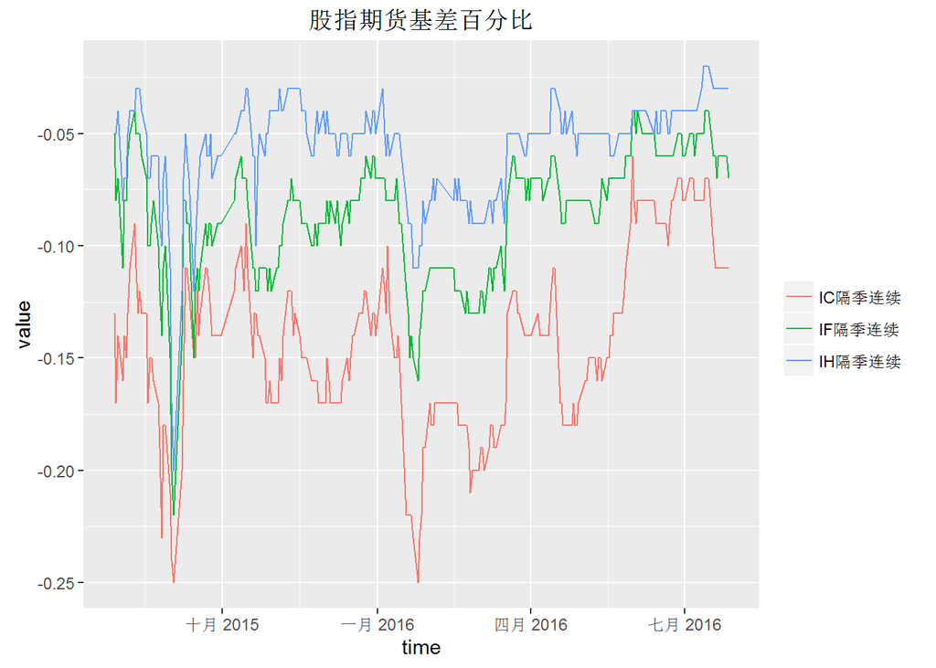

### (二)基差概况

三大股指期货连续合约基差概况如下表：

| 日期 | 合约简称 | 合约收盘价 | 基差 | 基差百分比 | 上周基差 | 上周基差百分比 |
| --- | --- | --- | --- | --- | --- | --- |
| 2016-07-27 | IH当月连续 | 2153.0 | -20.97 | -0.01 | -13.72 | -0.01 |
| 2016-07-27 | IH下月连续 | 2144.6 | -29.37 | -0.01 | -25.72 | -0.01 |
| 2016-07-27 | IH下季连续 | 2119.2 | -54.77 | -0.03 | -49.12 | -0.02 |
| 2016-07-27 | IH隔季连续 | 2105.8 | -68.17 | -0.03 | -70.52 | -0.03 |
| 2016-07-27 | IF当月连续 | 3163.0 | -55.24 | -0.02 | -41.61 | -0.01 |
| 2016-07-27 | IF下月连续 | 3137.0 | -81.24 | -0.03 | -73.21 | -0.02 |
| 2016-07-27 | IF下季连续 | 3058.0 | -160.24 | -0.05 | -154.61 | -0.05 |
| 2016-07-27 | IF隔季连续 | 2998.8 | -219.44 | -0.07 | -216.01 | -0.07 |
| 2016-07-27 | IC当月连续 | 6104.2 | -125.09 | -0.02 | -152.52 | -0.02 |
| 2016-07-27 | IC下月连续 | 5999.2 | -230.09 | -0.04 | -267.72 | -0.04 |
| 2016-07-27 | IC下季连续 | 5693.2 | -536.09 | -0.09 | -520.12 | -0.08 |
| 2016-07-27 | IC隔季连续 | 5514.6 | -714.69 | -0.11 | -717.32 | -0.11 |

## 三、套利

### (一)复牌股票套利

近两天复牌股票套利情况如下表：

[1] “无复牌股票套利”

### (二)定增基金跟踪

截止2016-07-28定增基金数据如下表，明细数据参见钱瀚的模板。

| 代码 | 名称 | 到期日期 | 最新净值 | 昨日收盘价 | 折溢价率 | 整体隐含折价率 | 大盘回撤0.1净值回撤 |
| --- | --- | --- | --- | --- | --- | --- | --- |
| 168101.OF | 九泰锐智 | 20200814 | 1.34 | 1.41 | 0.06 | 0.15 | -0.05 |
| 168102.OF | 九泰锐富 | 20210204 | 1.02 | 1.04 | 0.02 | 0.05 | -0.01 |
| 161222.OF | 国投瑞利 | 20160805 | 1.03 | 1.03 | -0.01 | 0.00 | -0.04 |
| 161225.OF | 国投瑞盈 | 20161119 | 1.01 | 1.01 | 0.00 | 0.05 | -0.07 |
| 501001.OF | 财通精选 | 20170101 | 1.08 | 1.03 | -0.04 | 0.02 | -0.09 |
| 501015.OF | 财通升级 | 20170908 | 1.01 | 1.00 | -0.02 | 0.08 | -0.03 |
| 160518.OF | 博时睿远 | 20171016 | 1.01 | 1.00 | 0.00 | 0.03 | -0.01 |

定增基金近期的净值走势如下图：

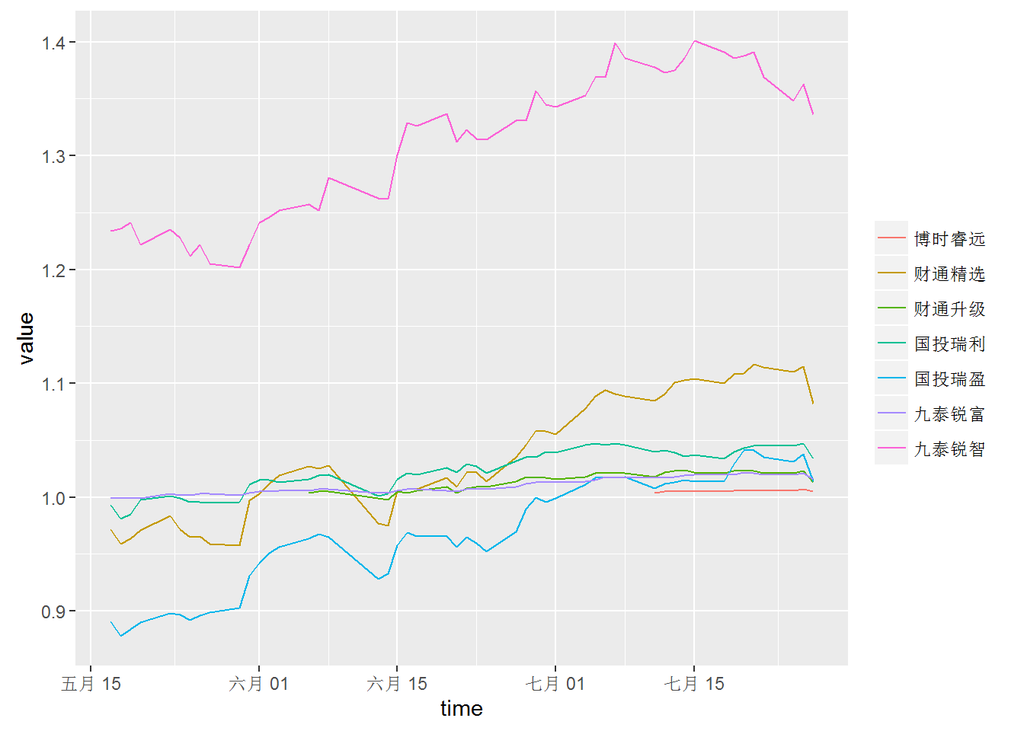

定增基金近期的折溢价走势如下图：

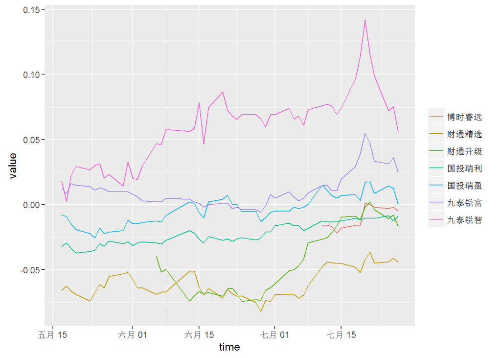

## 四、择时

### (一)大盘均线强弱指数

大盘均线强弱指数在一定程度上可以视为一个反转指标，当大盘均线得分接近8分时，预示市场接近顶部，当大盘均线得分接近0分时，预示市场接近底部。  
大盘均线强弱指数近一年来走势如下图：

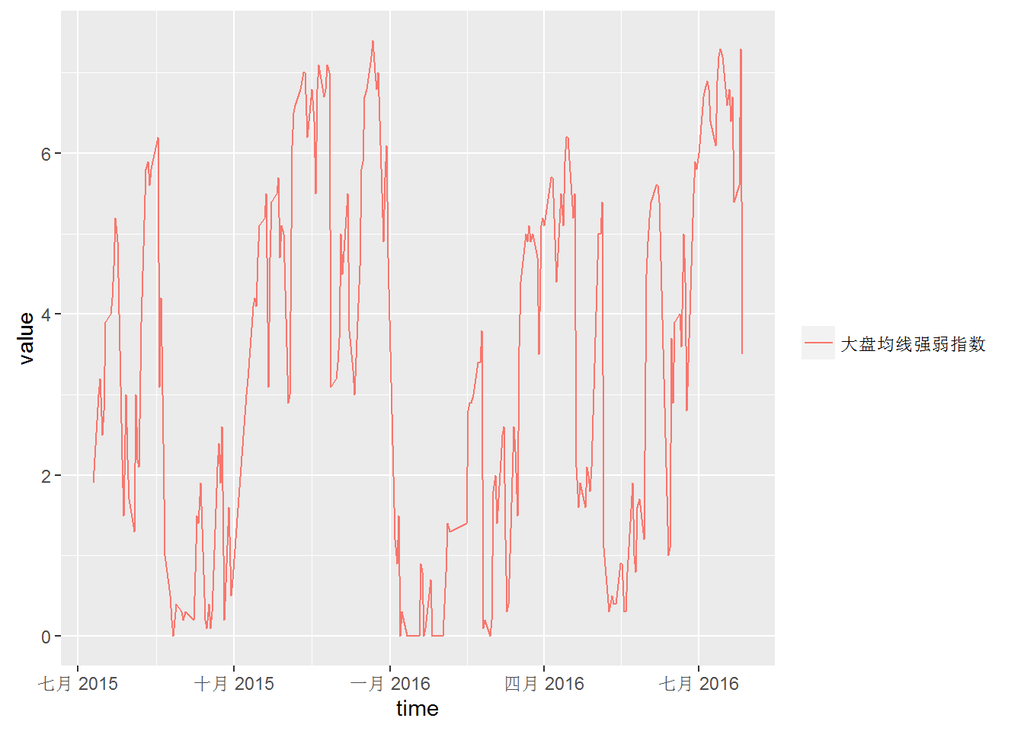

申万一级行业的最新得分及上周得分见下表：

| 日期 | 指数代码 | 指数名称 | 最新值 | 上周值 |
| --- | --- | --- | --- | --- |
| 2016-07-27 | EI801780 | 申万银行 | 8 | 6 |
| 2016-07-27 | EI801150 | 申万医药生物 | 6 | 8 |
| 2016-07-27 | EI801030 | 申万化工 | 5 | 8 |
| 2016-07-27 | EI801110 | 申万家用电器 | 5 | 7 |
| 2016-07-27 | EI801120 | 申万食品饮料 | 5 | 6 |
| 2016-07-27 | EI801230 | 申万综合 | 5 | 8 |
| 2016-07-27 | EI801770 | 申万通信 | 5 | 8 |
| 2016-07-27 | EI801010 | 申万农林牧渔 | 4 | 8 |
| 2016-07-27 | EI801020 | 申万采掘 | 4 | 6 |
| 2016-07-27 | EI801050 | 申万有色金属 | 4 | 6 |
| 2016-07-27 | EI801080 | 申万电子 | 4 | 8 |
| 2016-07-27 | EI801140 | 申万轻工制造 | 4 | 8 |
| 2016-07-27 | EI801710 | 申万建筑材料 | 4 | 8 |
| 2016-07-27 | EI801740 | 申万国防军工 | 4 | 5 |
| 2016-07-27 | EI801790 | 申万非银金融 | 4 | 5 |
| 2016-07-27 | EI801880 | 申万汽车 | 4 | 8 |
| 2016-07-27 | EI801160 | 申万公用事业 | 3 | 5 |
| 2016-07-27 | EI801720 | 申万建筑装饰 | 3 | 6 |
| 2016-07-27 | EI801730 | 申万电气设备 | 3 | 8 |
| 2016-07-27 | EI801750 | 申万计算机 | 3 | 7 |
| 2016-07-27 | EI801890 | 申万机械设备 | 3 | 7 |
| 2016-07-27 | EI801130 | 申万纺织服装 | 2 | 8 |
| 2016-07-27 | EI801170 | 申万交通运输 | 2 | 5 |
| 2016-07-27 | EI801200 | 申万商业贸易 | 2 | 7 |
| 2016-07-27 | EI801040 | 申万钢铁 | 1 | 3 |
| 2016-07-27 | EI801180 | 申万房地产 | 0 | 1 |
| 2016-07-27 | EI801210 | 申万休闲服务 | 0 | 3 |
| 2016-07-27 | EI801760 | 申万传媒 | 0 | 6 |

### (二)LLT及均线择时

LLT本质上是一个改进的单均线择时指标，较原始的均线择时延迟更低。  
择时模型和指数本身的净值走势如下图：

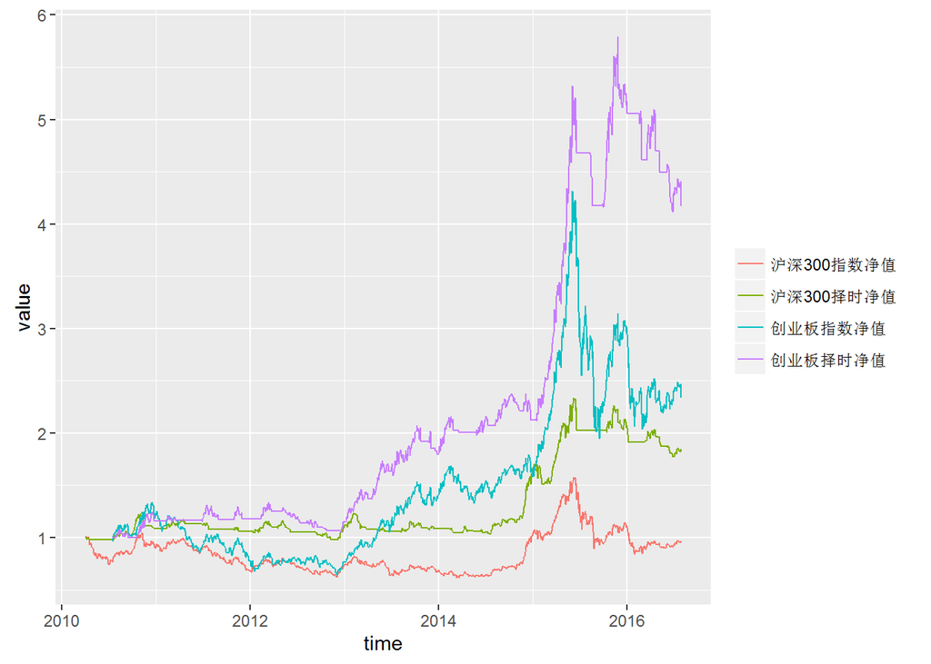

择时模型和指数的收益率统计如下表：

|  | 沪深300指 | 沪深300LLT | 创业板指 | 创业板MA |
| --- | --- | --- | --- | --- |
| 年化收益率 | -0.01 | 0.10 | 0.16 | 0.28 |
| 年化波动率 | 0.26 | 0.16 | 0.35 | 0.24 |
| 年化Sharpe值 | -0.03 | 0.63 | 0.45 | 1.15 |
| 最大回撤 | 0.47 | 0.24 | 0.55 | 0.29 |

择时模型最近10个交易日的信号如下表：

| 日期 | 沪深300收盘价 | 沪深300择时信号 | 创业板收盘价 | 创业板择时信号 |
| --- | --- | --- | --- | --- |
| 2016-07-14 | 3276.764 | hold | 2293.079 | hold |
| 2016-07-15 | 3276.278 | hold | 2263.784 | hold |
| 2016-07-18 | 3262.022 | hold | 2249.871 | hold |
| 2016-07-19 | 3248.234 | hold | 2273.719 | hold |
| 2016-07-20 | 3237.605 | hold | 2268.535 | hold |
| 2016-07-21 | 3252.523 | hold | 2265.128 | hold |
| 2016-07-22 | 3225.162 | hold | 2249.999 | hold |
| 2016-07-25 | 3230.885 | hold | 2245.885 | hold |
| 2016-07-26 | 3269.588 | hold | 2279.550 | hold |
| 2016-07-27 | 3218.243 | hold | 2155.386 | sell |

### (三)网格交易

在经历了三轮股灾，A股逐步回归正常，在过去的一段时间呈现一个震荡的格局，如果未来没有增量信息，很可能维持震荡。结合股指期货的贴水，前期研究了一下网格交易。网格交易的结果如下图：

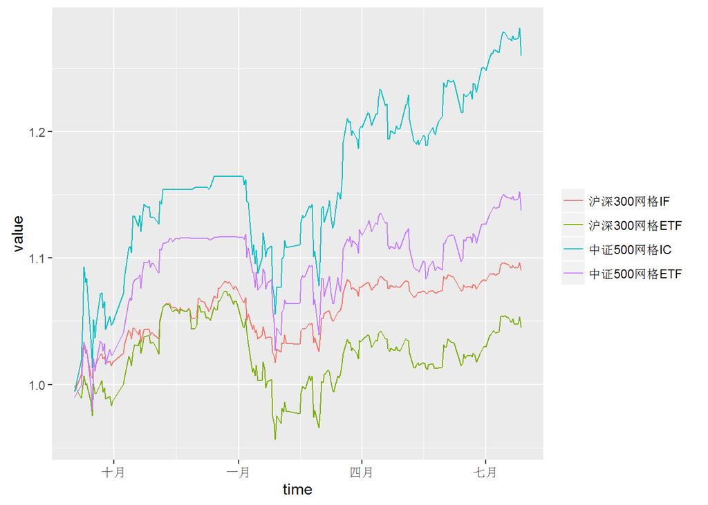

网格交易的收益统计如下表：

|  | 沪深300指数 | 沪深300网格IF | 沪深300网格ETF | 中证500指数 | 中证500网格IC | 中证500网格ETF |
| --- | --- | --- | --- | --- | --- | --- |
| 年化收益率 | -0.05 | 0.10 | 0.05 | 0.01 | 0.30 | 0.16 |
| 年化波动率 | 0.28 | 0.08 | 0.12 | 0.38 | 0.17 | 0.14 |
| 年化Sharpe值 | -0.17 | 1.30 | 0.43 | 0.03 | 1.74 | 1.15 |
| 最大回撤 | 0.26 | 0.06 | 0.11 | 0.33 | 0.09 | 0.08 |